# Classifier for Cancer

This is the basics for using the pyblight library to train a machine learnign model for cancer classification. The purpose of this library is to develop efficient tumor classifiers that will liberate radiologists from having to diagnose large number of patients based on image data all the while focusing on the rarer cases.

## Purpose of the notebook

- Show how machine learning algorithms and the pytorch library can be used to classify tumors
- How to set up data from the cancer imaging archive (tcia) for training ML models
- The result of images
- Process images for normalization

## Business Understanding

- Mortality rate for cancer has been increasing gradually throughout time
- Three general areas are used to measure the progress of the fight against cancer
  1. direct measures (mortality, incidence, and survival)
  2. portents of change (reductions in tobacco use)
  3. advances in knowledge that may have an effect on the future

## Data Preparation

- To use the image data, one first has to load the images from the dicom file.
- The data may be obfuscated within a set of folders that make organizing the images more difficult.
- We extract the data using built-in functions from the pyblight library
- A csv file was created containing the categorical data from the existing dataset csv files and the paths to all of the dicom files within the dataset.
  - This is used to load the images for training.

```python
import polars as pl

fn__dataset = "data/CMMD-Set/full_dataset_v2.csv"
df__dataset = pl.read_csv(fn__dataset)
df__dataset.head(10)
```

shape: (10, 8)

| path str | id str | LeftRight str | Age i64 | number i64 | abnormality str | classification str | subtype str |
| --- | --- | --- | --- | --- | --- | --- | --- |
| "data/CMMD-Set/… | "D1-1719" | "L" | 73 | 2 | "mass" | "Malignant" | null |
| "data/CMMD-Set/… | "D1-1719" | "L" | 73 | 2 | "mass" | "Malignant" | null |
| "data/CMMD-Set/… | "D1-0242" | "R" | 58 | 2 | "both" | "Benign" | null |
| "data/CMMD-Set/… | "D1-0242" | "R" | 58 | 2 | "both" | "Benign" | null |
| "data/CMMD-Set/… | "D2-0346" | "R" | 34 | 2 | "mass" | "Malignant" | "Luminal B" |
| "data/CMMD-Set/… | "D2-0346" | "R" | 34 | 2 | "mass" | "Malignant" | "Luminal B" |
| "data/CMMD-Set/… | "D2-0346" | "R" | 34 | 2 | "mass" | "Malignant" | "Luminal B" |
| "data/CMMD-Set/… | "D2-0346" | "R" | 34 | 2 | "mass" | "Malignant" | "Luminal B" |
| "data/CMMD-Set/… | "D1-0020" | "R" | 53 | 2 | "calcification" | "Benign" | null |
| "data/CMMD-Set/… | "D1-0020" | "R" | 53 | 2 | "calcification" | "Benign" | null |

The dataset above contains an id that leads to the patient's images, there are five categorical features (LeftRight, Age, abnormality, classification, and subtype). For the intent of training the models, only the classification column will be used.

Before the classification column can be used, it has to be transformed to a numerical representation.

```python
df__dataset = df__dataset.with_columns(pl.col('classification').cast(pl.Categorical))
list__categories = df__dataset.unique(subset=['classification']).get_column('classification').to_list()
labels = {label:i for i, label in enumerate(list__categories)}
inverted_labels = {v:k for k, v in labels.items()}
df__dataset = df__dataset.with_columns(pl.col('classification').replace(labels, default=None))
df__dataset.head(10)
```

shape: (10, 8)

| path str | id str | LeftRight str | Age i64 | number i64 | abnormality str | classification i64 | subtype str |
| --- | --- | --- | --- | --- | --- | --- | --- |
| "data/CMMD-Set/… | "D1-1719" | "L" | 73 | 2 | "mass" | 0 | null |
| "data/CMMD-Set/… | "D1-1719" | "L" | 73 | 2 | "mass" | 0 | null |
| "data/CMMD-Set/… | "D1-0242" | "R" | 58 | 2 | "both" | 1 | null |
| "data/CMMD-Set/… | "D1-0242" | "R" | 58 | 2 | "both" | 1 | null |
| "data/CMMD-Set/… | "D2-0346" | "R" | 34 | 2 | "mass" | 0 | "Luminal B" |
| "data/CMMD-Set/… | "D2-0346" | "R" | 34 | 2 | "mass" | 0 | "Luminal B" |
| "data/CMMD-Set/… | "D2-0346" | "R" | 34 | 2 | "mass" | 0 | "Luminal B" |
| "data/CMMD-Set/… | "D2-0346" | "R" | 34 | 2 | "mass" | 0 | "Luminal B" |
| "data/CMMD-Set/… | "D1-0020" | "R" | 53 | 2 | "calcification" | 1 | null |
| "data/CMMD-Set/… | "D1-0020" | "R" | 53 | 2 | "calcification" | 1 | null |

### The DICOM Files

The file type containing the images of the dataset are called Digital Imaging and Communications in Medicine (DICOM for short). This is meant to be a standard for medical images and the metadata associated with the aforementioned medical image. Each sample in the dataset may contain a myriad of images that represent a slice of the patient.

We first begin by loading the dicom file whose path was extracted from the dataframe using the pydicom library:

```python
from pydicom import dcmread

dicom_path = df__dataset.select(pl.col('path'))[0].item()
dicom_file = dcmread(dicom_path)
print(dicom_file)
```

```
Dataset.file_meta -------------------------------
(0002, 0000) File Meta Information Group Length  UL: 208
(0002, 0001) File Meta Information Version       OB: b'\x00\x01'
(0002, 0002) Media Storage SOP Class UID         UI: Digital Mammography X-Ray Image Storage - For Presentation
(0002, 0003) Media Storage SOP Instance UID      UI: 1.3.6.1.4.1.14519.5.2.1.1239.1759.102465487129565648408369510205
(0002, 0010) Transfer Syntax UID                 UI: Explicit VR Little Endian
(0002, 0012) Implementation Class UID            UI: 1.3.6.1.4.1.22213.1.143
(0002, 0013) Implementation Version Name         SH: '0.5'
(0002, 0016) Source Application Entity Title     AE: 'POSDA'
-------------------------------------------------
(0008, 0005) Specific Character Set              CS: 'ISO_IR 100'
(0008, 0008) Image Type                          CS: ['DERIVED', 'PRIMARY']
(0008, 0012) Instance Creation Date              DA: '20170818'
(0008, 0013) Instance Creation Time              TM: '122615'
(0008, 0014) Instance Creator UID                UI: 1.3.6.1.4.1.14519.5.2.1.1239.1759.256693145395574474618647257749
(0008, 0016) SOP Class UID                       UI: Digital Mammography X-Ray Image Storage - For Presentation
(0008, 0018) SOP Instance UID                    UI: 1.3.6.1.4.1.14519.5.2.1.1239.1759.102465487129565648408369510205
(0008, 0020) Study Date                          DA: '20110718'
(0008, 0021) Series Date                         DA: '20110718'
(0008, 0022) Acquisition Date                    DA: '20110718'
(0008, 0023) Content Date                        DA: '20110718'
(0008, 0030) Study Time                          TM: '000000'
(0008, 0031) Series Time                         TM: '000000'
(0008, 0032) Acquisition Time                    TM: '000000'
(0008, 0033) Content Time                        TM: '000000'
(0008, 0050) Accession Number                    SH: ''
(0008, 0060) Modality                            CS: 'MG'
(0008, 0068) Presentation Intent Type            CS: 'FOR PRESENTATION'
(0008, 0070) Manufacturer                        LO: ''
(0008, 0090) Referring Physician's Name          PN: ''
(0008, 2218)  Anatomic Region Sequence  1 item(s) ----
   (0008, 0100) Code Value                          SH: '76752008'
   (0008, 0102) Coding Scheme Designator            SH: 'SCT'
   (0008, 0104) Code Meaning                        LO: 'Breast'
   ---------
(0010, 0010) Patient's Name                      PN: 'D1-1719'
(0010, 0020) Patient ID                          LO: 'D1-1719'
(0010, 0030) Patient's Birth Date                DA: ''
(0010, 0040) Patient's Sex                       CS: 'F'
(0010, 1010) Patient's Age                       AS: '073Y'
```

[output cut: 64 more lines]

```
(0028, 1053) Rescale Slope                       DS: '1.0'
(0028, 1054) Rescale Type                        LO: 'US'
(0028, 1055) Window Center & Width Explanation   LO: 'Full width of 8 bit data'
(0028, 1056) VOI LUT Function                    CS: 'SIGMOID'
(0028, 2110) Lossy Image Compression             CS: '00'
(0040, 0318) Organ Exposed                       CS: 'BREAST'
(0040, 0555)  Acquisition Context Sequence  0 item(s) ----
(0054, 0220)  View Code Sequence  1 item(s) ----
   (0008, 0100) Code Value                          SH: '399162004'
   (0008, 0102) Coding Scheme Designator            SH: 'SCT'
   (0008, 0104) Code Meaning                        LO: 'cranio-caudal'
   (0054, 0222)  View Modifier Code Sequence  0 item(s) ----
   ---------
(2050, 0020) Presentation LUT Shape              CS: 'IDENTITY'
(7fe0, 0010) Pixel Data                          OB: Array of 4390716 elements
```

As shown above, the loaded diucom file contains textual data associated with the medical image itself. In a hospital setting, the dicom file will contain personal patient information (such as age, height, weight, etc). Due to the anonymization process for the patient's safety, many fields have been removed. Now that hte dicom file has been loaded, one can work towards extracting the image(s).

```
(2294, 1914)
```

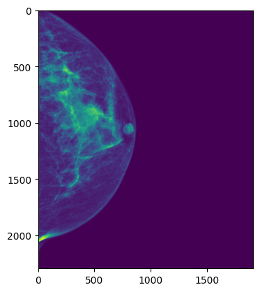

```python
import matplotlib.pyplot as plt
%matplotlib inline
img = dicom_file.pixel_array
plt.imshow(img)
print(img.shape)
```

As shown above, the image is currently of a very high resolution (2294, 1914). This is not ideal for machine learning as the amount of data extracted from each individual pixel scales the model to a very large size (possibly within the terabites level). Ideally, one would extract region(s) of of interest from the image which would be smaller than the image resolution and make the model lighter. For now, the image will be rescaled to a more proportionate size (512, 512).

From here on, the three models will be loaded and the test and validation tests will be used observe the results.

## Data Modeling

Before we load the trained models and test them, we first need to load the validation and test datasets. We begin by first creating the transformations required for testing the models on the datasets.

```python
from torchvision import transforms
import torch

img_trans = transforms.Compose([
    transforms.ToTensor(),
    transforms.Resize((512, 512), antialias=True),
    transforms.Grayscale(num_output_channels=1),
    transforms.Normalize((0.5), (0.5))
])

cat_trans = transforms.Lambda(lambda y: torch.zeros(2, dtype=torch.float).scatter_(dim=0, index=torch.tensor(y), value=1))
```

Now that the transformations have been created, one can load the datasets from their respective csv files. After loading the data one can use a custom DataSet, transform the data and load it unto the dataloader for model testing.

```python
from src.datasets import DICOMSet
from torch.utils import data
import json #Load the dictionary and use it to transform the classification column

fn__test = 'data/CMMD-Set/test_set.csv'
fn__valid = 'data/CMMD-Set/valid_set.csv'
with open('data/CMMD-Set/label.json', 'r') as fp:
    dict__labels = json.load(fp)
    fp.close()

classes = ('malignant', 'benign')

df__test = pl.read_csv(fn__test)
df__test = df__test.with_columns(pl.col('classification').replace(dict__labels, default=None))
df__valid = pl.read_csv(fn__valid)
df__valid = df__valid.with_columns(pl.col('classification').replace(dict__labels, default=None))

test_set = DICOMSet(df__test, label_col='classification', image_transforms=img_trans, categorical_transforms=cat_trans)
test_loader = data.DataLoader(test_set, shuffle=True, batch_size=32, num_workers=8)
valid_set = DICOMSet(df__valid, label_col='classification', image_transforms=img_trans, categorical_transforms=cat_trans)
valid_loader = data.DataLoader(valid_set, shuffle=True, batch_size=32, num_workers=8)
```

```python
from src.trainers import TrainModel
from src.models import AlexNet, CustomCNN, InceptionV4

model1 = AlexNet()
model1.load_state_dict(torch.load('models/alexnet_final_v2.pt'))
model1.eval()
TrainModel.test(model1, test_loader, classes, gpu=True, version=0)
TrainModel.test(model1, valid_loader, classes, gpu=True, version=1)
model2 = CustomCNN()
model2.load_state_dict(torch.load('models/customcnn_final_v2.pt'))
model2.eval()
TrainModel.test(model2, test_loader, classes, gpu=True, version=0)
TrainModel.test(model2, valid_loader, classes, gpu=True, version=1)
model3 = InceptionV4(n_classes=2, n_channels=1)
model3.load_state_dict(torch.load('models/inceptionv4_final_v2.pt'))
model3.eval()
TrainModel.test(model3, test_loader, classes, gpu=True, version=0)
TrainModel.test(model3, valid_loader, classes, gpu=True, version=1)
```

```
Accuracy for class: malignant is 100.0%
Accuracy for class: benign is 0.0%
Accuracy for class: malignant is 100.0%
Accuracy for class: benign is 0.0%
Accuracy for class: malignant is 96.1%
Accuracy for class: benign is 5.9%
Accuracy for class: malignant is 95.9%
Accuracy for class: benign is 2.1%
Accuracy for class: malignant is 98.2%
Accuracy for class: benign is 0.3%
Accuracy for class: malignant is 98.0%
Accuracy for class: benign is 1.8%
```